# USA Home Sales

Cevi Herdian & Jaber Zaher Aldeen

07.01.2019

**Hinweis:**

-Ein R Notebook ist ein R Markdown-Dokument mit R Skripten, die unabhängig und interaktiv ausgeführt werden können, wobei die Ausgabe unmittelbar unter der Eingabe sichtbar ist.

-Die Notebook-Ausgabe ist als HTML, PDF, Word oder Latex verfügbar.

-Dieses Notebook als HTML ist vorzugsweise mit Web Browser (zb. Chrome) zu öffnen.

-R-Skripten kann als Rmd-Datei unter dem Button “Code” ( oben rechts) im Notebook extrahiert werden.

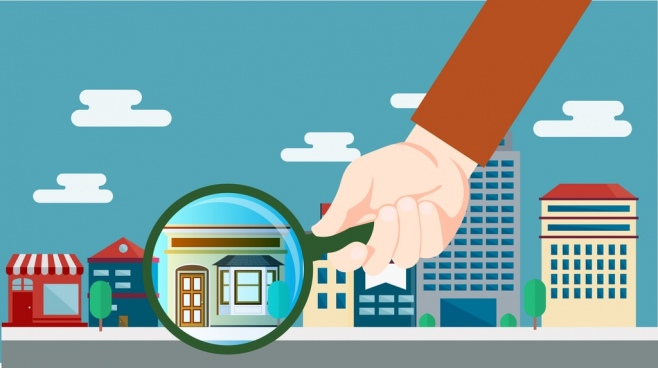

```r
#quelle: https://all-free-download.com/free-vector/housing-buildings-icon.html
```

## 1. Hintergrund und Ziel der Analyse

**Der Sales ist das Lebenselixier eines Unternehmens**. Die Vorteile der Salesprognose können Sie sich ein genaues Bild machen, was Sie in den kommenden Monaten erwartet. Eine Standard-Verkaufsprognose betrachtet die Bedingungen in Ihrem Unternehmen in den Vormonaten und wendet dann Annahmen über die Kundengewinnung, die Wirtschaft und Ihr Produkt-und Dienstleistungsangebot an.

**Die Salesprognose ist ein Schlüsselelement bei der Durchführung Ihres Unternehmens**. Der Realismus, den eine gute Prognose bietet, kann Ihnen helfen, Ihre strategischen Pläne zu entwickeln und zu verbessern

Die Prognose können Aspekte Ihres Unternehmens verwalten, unter anderem:

- Anzahl der Entscheidungen, von der Einstellung und dem Ressourcenmanagement bis hin zur **Zielsetzung und Budgetierung**.
- Marketing
- Inventor kontrollen
- usw

```r
#quelle: https://yourbusiness.azcentral.com/advantages-sales-forecasting-10308.html
#quelle: https://blog.hubspot.com/sales/sales-forecasting
```

Die Salesprognose identifiziert Schwachstellen und Stärken, bevor Sie Ihre Budget- und Marketingpläne für das nächste Zeitraum festlegen, so dass Sie Ihre Einkaufs- und Expansionspläne optimieren können.

Die Daten sind unter folgender URL abrufbar: [USA Home Sales](https://datamarket.com/data/set/22q8/monthly-sales-of-new-one-family-houses-sold-in-th-e-usa-since-1973#!ds=22q8&display=line)

## 2. Einlesen der Daten

### Importieren der Daten

```r
#Zuerst bitte setwd() in unsre file directory eingerichtet (Ordnen, wo der Daten liegen)
sales<-read.csv(file="sales.csv", header=TRUE,sep = ",")
head(sales, 5) #nur 5 Zeilen hat so gezeigt
```

|  | Month | Monthly.sales.of.new.one.family.houses.sold.in.th.e.USA.since.1973 |
| --- | --- | --- |
| 1 | 1973-01 | 55 |
| 2 | 1973-02 | 60 |
| 3 | 1973-03 | 68 |
| 4 | 1973-04 | 63 |
| 5 | 1973-05 | 65 |

```r
dim(sales) #dimension der daten
```

```
[1] 277   2
```

```r
class(sales) #class der daten
```

```
[1] "data.frame"
```

```r
#Umbennen der Spaltenname
name<-c("month","sales")
names(sales)<-name
head(sales,5)
```

|  | month | sales |
| --- | --- | --- |
| 1 | 1973-01 | 55 |
| 2 | 1973-02 | 60 |
| 3 | 1973-03 | 68 |
| 4 | 1973-04 | 63 |
| 5 | 1973-05 | 65 |

Also die Daten hat 275 Zeilen (277-2) und 2 Spalten (datum und anzahl der Wohnungen ) as “data.frame”. Es geht um CSV Tabelle Formatierung.

> Vorsicht! die Daten ist monatlichen Daten von Jan 1973 - Nov 1995.

### Erstellen ts (time series) object

Die Daten sind nicht ts object sondern dataframe. Wir müssen die Daten nach ts object konvertieren. Es gibt vielen Methoden um die Daten nach ts object zu konvertieren. Wir haben mit packages `fpp`(Data for “Forecasting principles and practice”) gewählt.

** Erstellen times series object mit fpp packagen: **

```r
#install.packages("fpp")
#library(fpp)
sales_ts<-ts(sales$sales,frequency=12,start=c(1973))
sales_ts
```

```
     Jan Feb Mar Apr May Jun Jul Aug Sep Oct Nov Dec
1973  55  60  68  63  65  61  54  52  46  42  37  30
1974  37  44  55  53  58  50  48  45  41  34  30  24
1975  29  34  44  54  57  51  51  53  46  46  46  39
1976  41  53  55  62  55  56  57  59  58  55  49  47
1977  57  68  84  81  78  74  64  74  71  63  55  51
1978  57  63  75  85  80  77  68  72  68  70  53  50
1979  53  58  73  72  68  63  64  68  60  54  41  35
1980  43  44  44  36  44  50  55  61  50  46  39  33
1981  37  40  49  44  45  38  36  34  28  29  27  29
1982  28  29  36  32  36  34  31  36  39  40  39  33
1983  44  46  57  59  64  59  51  50  48  51  45  48
1984  52  58  63  61  59  58  52  48  53  55  42  38
1985  48  55  67  60  65  65  63  61  54  52  51  47
1986  55  59  89  84  75  66  57  52  60  54  48  49
1987  53  59  73  72  62  58  55  56  52  52  43  37
1988  43  55  68  68  64  65  57  59  54  57  43  42
1989  52  51  58  60  61  58  62  61  49  51  47  40
1990  45  50  58  52  50  50  46  46  38  37  34  29
1991  30  40  46  46  47  47  43  46  37  41  39  36
1992  48  55  56  53  52  53  52  56  51  48  42  42
1993  44  50  60  66  58  59  55  57  57  56  53  51
1994  45  58  74  65  65  55  52  59  54  57  45  40
1995  47  47  60  58  63  64  64  63  55  54  44  NA
1996  NA
```

Es gibt NA werten, also bereinigen wir direkt vor dem Analyse. Denn NA werte zerstört die Aggregation.

Für nächstes Schritt brauchen wir aber daten ohne NA:

```r
sales_ts_ohne_na<-na.remove(sales_ts) #vorsicht na.remove liegt in fpp package
class(sales_ts_ohne_na)
```

```
[1] "ts"
```

**Plot der Daten:**

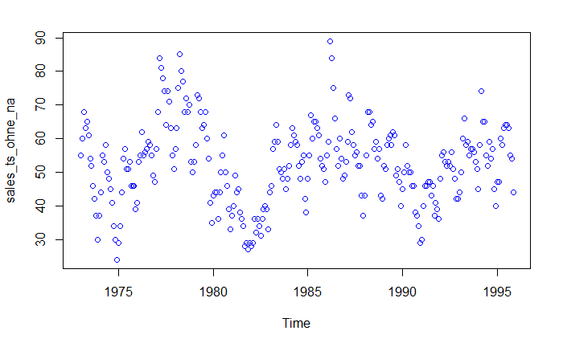

```r
plot.ts(sales_ts_ohne_na, type="p", col="blue", lty="dashed")
```

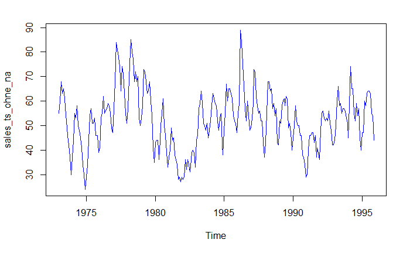

```r
ts.plot(sales_ts_ohne_na,col="blue") #plot mit linien type
```

** Wichtigen empirischen Kennzahlen in Plot hinzufügen: **

```r
plot(sales_ts_ohne_na,col="blue")
#Mittelwert berechnen
mw=mean(sales_ts_ohne_na)
mw
```

```
[1] 52.28727
```

```r
#Mittelwert in Plot hinzufügen
x=c(1973:1995,4)
#length(x)
y=rep(mw,24)
#length(y)
lines(x,y,col=2)
```

```r
#Varianz berechnen
var(sales_ts_ohne_na)
```

```
[1] 142.534
```

```r
#Standardabweichung berechnen
std=sd(sales_ts_ohne_na)
std
```

```
[1] 11.93876
```

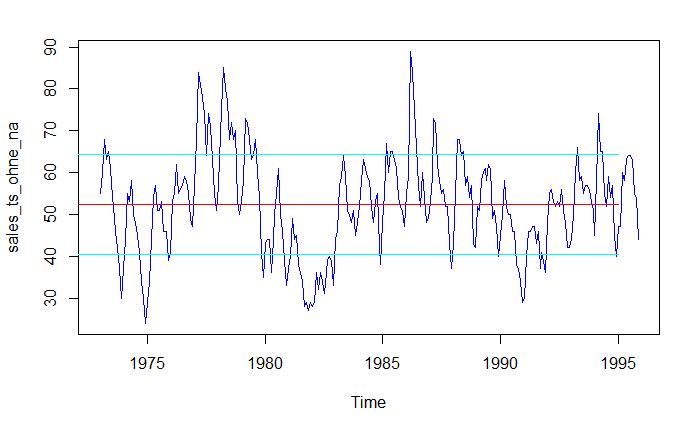

```r
# std einzeichnen
z1=rep(std+mw,24)
z2=rep(-std+mw,24)
#length(y)
lines(x,z1,col=5)
lines(x,z2,col=5)
```

**Interactiven Plot der Daten:**

In R kann man interactiven visualisierung erstellen. Viele packagen oder methoden für diesem Zweck. Mehr informationen über https://www.htmlwidgets.org/

Wir haben `dygraphs` package gewählt.

```r
#install dygraphs und ggplot2 package
dygraph(sales_ts, main = "Monatlicher Verkauf von neuen Einfamilienhäusern") %>%
  dyRangeSelector(dateWindow = c("1973-01-01", "1995-01-11"))
```

[interactive chart not shown]

## 3. Zeitreihenanalyse

### Was sind die Komponenten einer Zeitreihe?

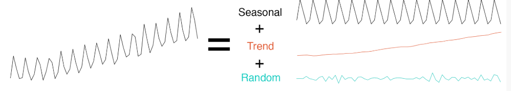

**Ziel:**

Wir wollen also möglichst mit stationären Prozessen arbeiten, noch besser mit linearen. Aber Prozesse mit

- Trend
- Saisonalen

Schwankungen sind nicht stationär. Daher versucht man, sie stationär zu machen

—> Trendbereinigung und Saisonbereinigung.

### Additive or Multiplicative Zeitreihen?

Um eine erfolgreiche `Trendbereinigung und Saisonbereinigung` zu erreichen, ist es wichtig, zwischen dem additiven und dem multiplikativen Modell zu wählen, was eine Analyse der Zeitreihen erfordert.

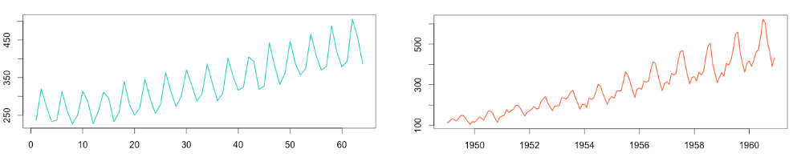

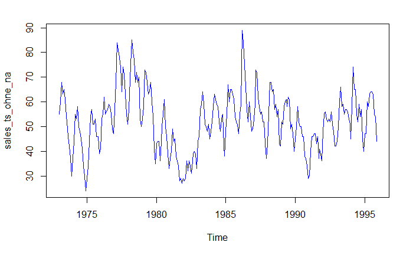

```r
plot.ts(sales_ts_ohne_na,col="blue") #ohne log
```

Um symmetrisch zu machen, fügen wir log funktion ein.

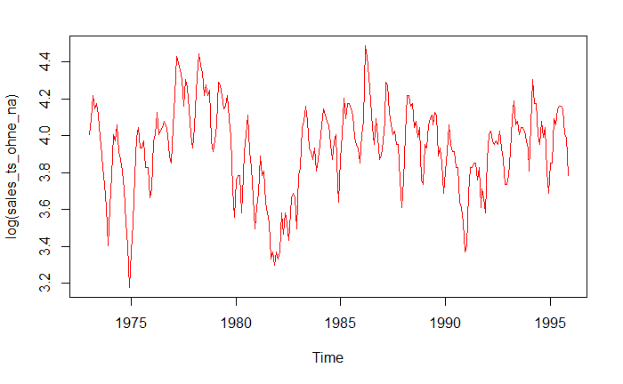

```r
plot.ts(log(sales_ts_ohne_na),col="red") #mit log
```

Mit und ohne log funktion ist ähnlich (Also nehmen wir ohne log funktion).

### Schrit per schritt Zeitreihenanalyse

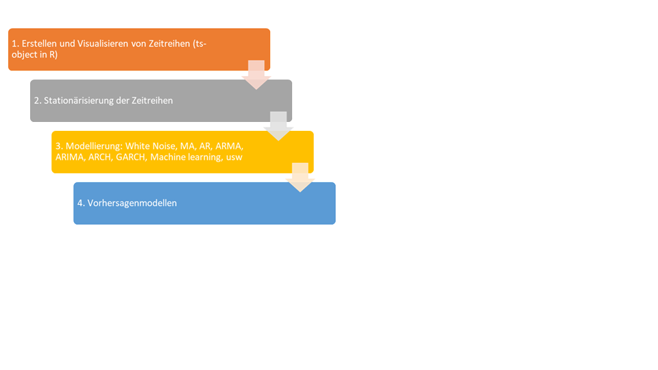

### Stationäre Prüfen

Es gibt einigen Methoden um Stationarität zu prüfen, unter anderem:

**1. Mit White Noise**

White Noise das einfachste Beispiel für einen stationären Prozess. Am Besten ist Gausches White Noise wegen folgenden Gründen.

- Vorhersagbarkeit: Wenn Ihre Zeitreihe White Noise ist, dann ist es per Definition zufällig. Du kannst es nicht vernünftig modellieren und Vorhersagen treffen.
- Modelldiagnose: Die Fehlerreihe eines Zeitreihen-Prognosemodells sollte idealerweise White Noise sein.
- Gauss oder Normal distribution ist wichtige Verteilung wegen einigen Gründen

Um White Noise zu identifizeren nutzt man `ACF` (erste Identification) und `Ljung-Box-Pierce-Test` (Unkorreliert).

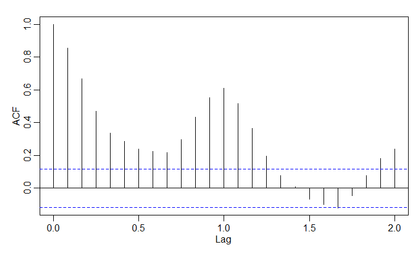

```r
par(mfrow=c(1,1), mar=c(3,3,1,0)+.5, mgp=c(1.6,.6,0))
acf(sales_ts_ohne_na)
```

```r
Box.test(sales_ts_ohne_na, lag=30, type="Ljung-Box")
```

```
    Box-Ljung test

data:  sales_ts_ohne_na
X-squared = 1025.2, df = 30, p-value < 2.2e-16
```

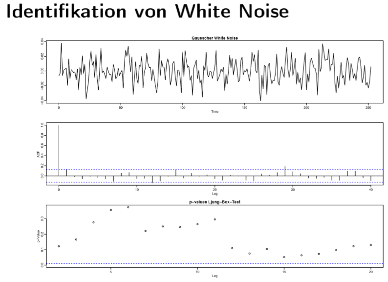

```r
#quelle: Zeitreihenanalyse Skripten SS2018, Prof. Dr. Irina Penner, HTW Berlin
```

**2. Anderen Test** (Unkorreliert) z.B: Augmented Dickey Fuller test, Phillipps-Perron test, Zivot-Andrews test, ADF-GLS test.

- Augmented Dickey-Fuller test:

```r
#install.packages("tseries")
#library(tseries)
adf.test(sales_ts_ohne_na)
```

```
    Augmented Dickey-Fuller Test

data:  sales_ts_ohne_na
Dickey-Fuller = -3.9397, Lag order = 6, p-value = 0.01247
alternative hypothesis: stationary
```

- Phillipps-Perron test:

```r
pp.test(sales_ts_ohne_na)
```

```
p-value smaller than printed p-value
```

```
    Phillips-Perron Unit Root Test

data:  sales_ts_ohne_na
Dickey-Fuller Z(alpha) = -44.195, Truncation lag parameter = 5, p-value = 0.01
alternative hypothesis: stationary
```

**3. Falls die Residuen (ut) unabhängig und normalverteilt sind?**

QQ-Plots und Histogramm (nach dem Trendbereinigung und Saisonbereinigung: die Residuen)

### Extraktion von Saisonalität und Trend

Es gibt einigen Methoden um Trend oder Saison zu zerlegen, unter anderem:

- Trend zerlegen: -> Trendresiduen= Data-Season
  - Global Trend
    - Linear
    - Nicht linear
  - Lokal Trend
    - Einfache gleitende Durchschnitte
    - Differenzfilter
    - Faltung: Hintereinanderausführung von Filtern
- Saison bereinigung: -> Saisonresiduen = Daten - Trend
  - Phasendurchschnittsverfahren
  - Regression mittels Saison-Dummies
  - Regression mit trigonometrischen Polynomen
  - Differenzenbildung
  - Viele etablierte Verfahren als Mischung aus diesen Methoden

**Direkt: `DECOMPOSE( )` and `STL()`: Time Series Decomposition in R**

Um das Leben einfacher zu machen, bieten einige R-Pakete eine Zerlegung mit einer einzigen Zeile Code.

DECOMPOSE():

```r
decompose(sales_ts_ohne_na, type = "additive")
```

```
$`x`
Time Series:
Start = c(1973, 1)
End = c(1995, 11)
Frequency = 12
  [1] 55 60 68 63 65 61 54 52 46 42 37 30 37 44 55 53 58 50 48 45 41 34 30 24 29 34 44 54 57 51 51
 [32] 53 46 46 46 39 41 53 55 62 55 56 57 59 58 55 49 47 57 68 84 81 78 74 64 74 71 63 55 51 57 63
 [63] 75 85 80 77 68 72 68 70 53 50 53 58 73 72 68 63 64 68 60 54 41 35 43 44 44 36 44 50 55 61 50
 [94] 46 39 33 37 40 49 44 45 38 36 34 28 29 27 29 28 29 36 32 36 34 31 36 39 40 39 33 44 46 57 59
[125] 64 59 51 50 48 51 45 48 52 58 63 61 59 58 52 48 53 55 42 38 48 55 67 60 65 65 63 61 54 52 51
[156] 47 55 59 89 84 75 66 57 52 60 54 48 49 53 59 73 72 62 58 55 56 52 52 43 37 43 55 68 68 64 65
[187] 57 59 54 57 43 42 52 51 58 60 61 58 62 61 49 51 47 40 45 50 58 52 50 50 46 46 38 37 34 29 30
[218] 40 46 46 47 47 43 46 37 41 39 36 48 55 56 53 52 53 52 56 51 48 42 42 44 50 60 66 58 59 55 57
[249] 57 56 53 51 45 58 74 65 65 55 52 59 54 57 45 40 47 47 60 58 63 64 64 63 55 54 44
attr(,"na.removed")
```

[output cut: 145 more lines]

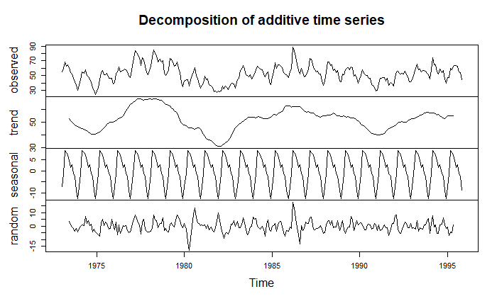

```r
dec=decompose(sales_ts_ohne_na)
plot(dec)
```

```r
plot(sales_ts_ohne_na, main="Sales ", ylab="")
lines((dec$trend), col=4)
```

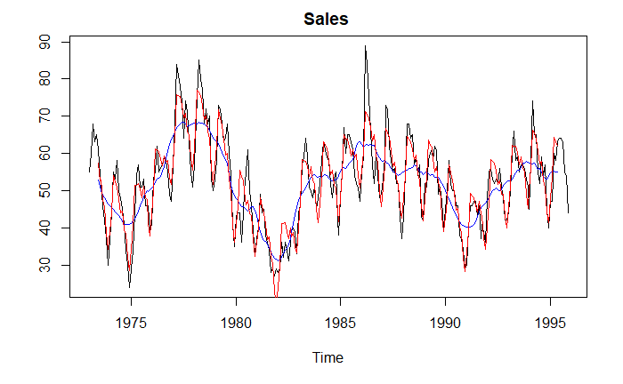

```r
lines((dec$seasonal+dec$trend), col=2)
```

STL():

```r
par(mfrow=c(1,1))
dec.pass=stl(sales_ts_ohne_na,"periodic")
dec.pass
```

```
 Call:
 stl(x = sales_ts_ohne_na, s.window = "periodic")

Components
          seasonal    trend     remainder
Jan 1973 -7.052493 61.82257   0.229924553
Feb 1973 -1.230381 60.22258   1.007797644
Mar 1973 -1.230381 58.62260  10.607783268
Apr 1973 -1.230381 57.06243   7.167954891
May 1973 -1.230381 55.50225  10.728126513
Jun 1973 -1.230381 54.00072   8.229659946
Jul 1973 -1.230381 52.49919   2.731193379
Aug 1973 -1.230381 51.05776   2.172624177
Sep 1973 -1.230381 49.61633  -2.385945024
Oct 1973 -1.230382 48.47375  -5.243364787
Nov 1973 -1.230382 47.33117  -9.100784549
Dec 1973 -1.230382 46.71048 -15.480098727
Jan 1974 -1.230382 46.08979  -7.859412905
Feb 1974 -7.052493 45.68398   5.368513088
Mar 1974 -1.230381 45.27817  10.952215020
Apr 1974 -1.230381 44.83067   9.399713294
May 1974 -1.230381 44.38317  14.847211579
Jun 1974 -1.230381 43.73419   7.496194529
Jul 1974 -1.230381 43.08520   6.145177480
Aug 1974 -1.230381 42.27816   3.952222771
Sep 1974 -1.230381 41.47111   0.759268063
Oct 1974 -1.230381 40.95995  -5.729568248
Nov 1974 -1.230382 40.44879  -9.218404558
Dec 1974 -1.230382 40.52756 -15.297176051
Jan 1975 -1.230382 40.60633 -10.375947545
Feb 1975 -7.052493 41.25403  -0.201534597
Mar 1975 -1.230381 41.90173   3.328654211
Apr 1975 -1.230381 42.99659  12.233795016
May 1975 -1.230381 44.09145  14.138935831
Jun 1975 -1.230381 45.38910   6.841279047
Jul 1975 -1.230381 46.68676   5.543622263
Aug 1975 -1.230381 47.76362   6.466758666
Sep 1975 -1.230381 48.84049  -1.610104931
Oct 1975 -1.230381 49.39289  -2.162510337
Nov 1975 -1.230382 49.94530  -2.714915742
```

[output cut: 225 more lines]

```
Sep 1994 -1.230381 54.47325   0.757127815
Oct 1994 -1.230381 54.05382   4.176559377
Nov 1994 -1.230382 53.63439  -7.404009061
Dec 1994 -1.230382 53.80952 -12.579137363
Jan 1995 -1.230382 53.98465  -5.754265665
Feb 1995 -7.052493 54.40554  -0.353043748
Mar 1995 -1.230381 54.82643   6.403954028
Apr 1995 -1.230381 55.09259   4.137791239
May 1995 -1.230381 55.35875   8.871628459
Jun 1995 -1.230381 55.64907   9.581308573
Jul 1995 -1.230381 55.93939   9.290988686
Aug 1995 -1.230381 56.30171   7.928676013
Sep 1995 -1.230381 56.66402  -0.433636660
Oct 1995 -1.230381 57.05055  -1.820166184
Nov 1995 -1.230382 57.43708 -12.206695709
```

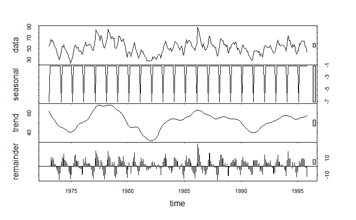

```r
plot(dec.pass)
#plot daten und modell
par(mfrow=c(3,1), mar=c(3,2,1,0)+.5, mgp=c(1.6,.6,0))
```

```r
plot(sales_ts_ohne_na, main="Sales: saisonale Zerlegung mit stl", ylab="")
lines((dec.pass$time.series[,2]), col=4)
```

```r
lines((dec.pass$time.series[,2]+dec.pass$time.series[,1]), col=2)
#Residuen
residuen=dec.pass$time.series[,3]
plot(residuen)
```

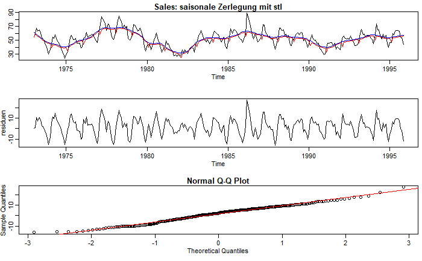

```r
qqnorm(residuen)
qqline(residuen, col=2)
```

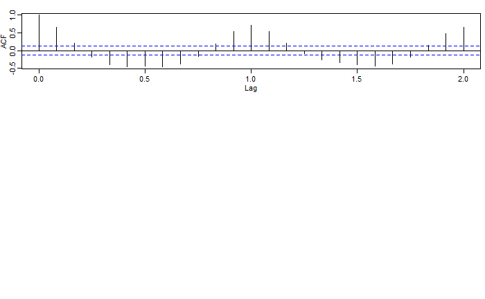

```r
acf(residuen)
```

```r
#Rquadrat(exp(dec.pass$time.series[,2]+dec.pass$time.series[,1]), passb) #Bestimmheitmaß
```

## 4. Modellen

### AR Modelle:

**1. ACF und PACF als erste identifikation:**

- ACF: exponential abklingelnd
- PACF: ordnung (Grad) der Modellen: der PACF bricht ab (außer KI: 95%)

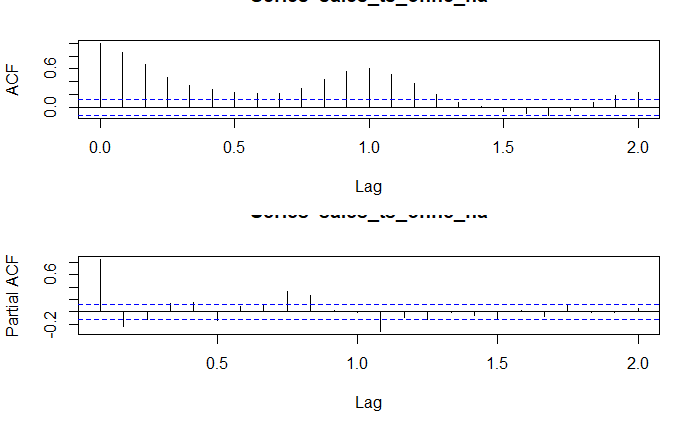

```r
par(mfrow=c(2,1))
acf(sales_ts_ohne_na)
pacf(sales_ts_ohne_na)
```

[output not shown]

[output cut: 34 more lines]

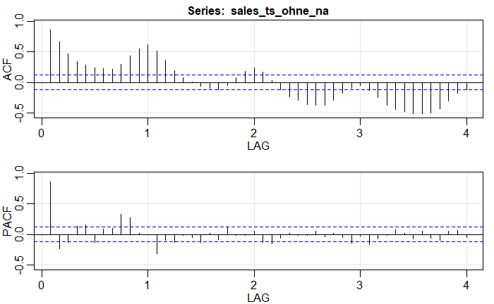

```r
#oder
acf2(sales_ts_ohne_na)
```

Kandidaten: 1, 2, 3,4,5….usw

**2. Schätzen von AR-Parametern:**

- Conditional bzw. Unconditional Least Sum of Squares (CLS bzw. ULS)
- Conditional bzw. Unconditional Maximum Likelihood (CML bzw. UML)
- Burg
- Yule Walker (YW)

```r
#Ordnung suchen
mm1_mle=ar.mle(sales_ts_ohne_na)
mm1_mle$order # Ordnung suchen
```

```
[1] 10
```

```r
mm2_yw=ar.yw(sales_ts_ohne_na)
mm2_yw$order # Ordnung suchen
```

```
[1] 15
```

```r
mm3_ols=ar.ols(sales_ts_ohne_na)
mm3_ols$order # Ordnung suchen
```

```
[1] 21
```

```r
mm4_burg=ar.burg(sales_ts_ohne_na)
mm4_burg$order # Ordnung suchen
```

```
[1] 21
```

Graphische Vergleich jeweils methoden:

```r
#Graphic Ordnung suchen
aic=mm1_mle$aic  # For plotting below.
plot(c(0:(length(aic)-1)),aic,type='h',xlab='order',ylab='aic')
lines(0:(length(mm2_yw$aic)-1), mm2_yw$aic, lty=4, col=2)
```

```r
lines(0:(length(mm3_ols$aic)-1), mm3_ols$aic, lty=4, col=3)
lines(0:(length(mm4_burg$aic)-1), mm4_burg$aic, lty=4, col=4)
```

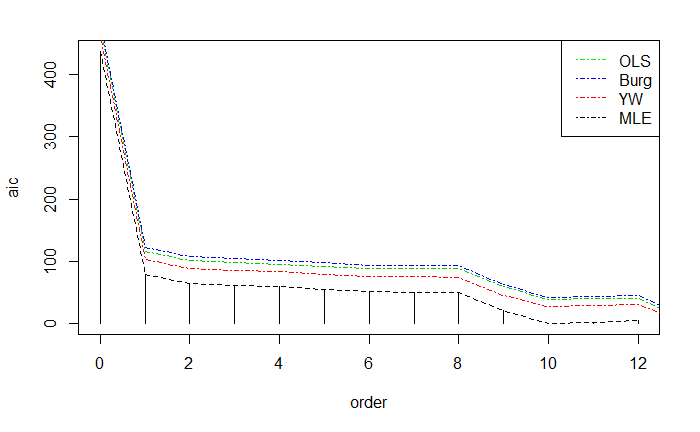

```r
lines(0:(length(aic)-1),aic,lty=2)
colors <- c("green","blue","red", "black")
legend("topright", c(paste("OLS"),
                     paste("Burg"),
                     paste("YW"),
                     paste("MLE")),
       lwd = 1, cex=1, col=colors, pt.lwd = 1, lty=4)
```

Graphische Vergleich der Modellen:

```r
#Grafischer Vergleich
plot(sales_ts_ohne_na, main="Vergleich Modelle")
lines(fitted(mm2_yw),col="blue")
```

```r
lines(fitted(mm1_mle),col="red")
lines(fitted(mm3_ols),col=6)
```

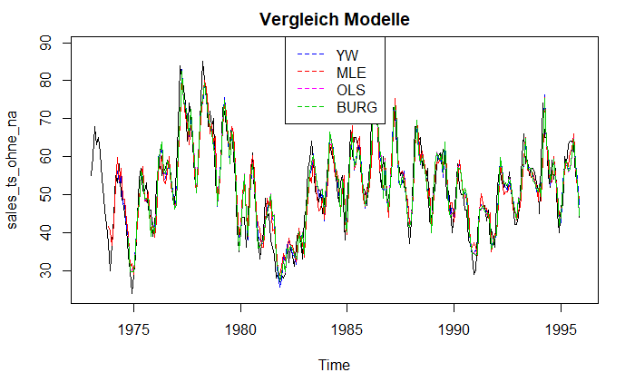

```r
lines(fitted(mm4_burg),col=3)
colors <- c("blue","red",6, 3)
legend("top", c(paste("YW"),
                paste("MLE"),
                paste("OLS"),
                paste("BURG")),
       lwd = 1, cex=1, col=colors, pt.lwd = 1, lty=2)
```

**3. Gute der Modellen direkt mit `sarima()`:**

Fazit: Ordnung Kandidaten sind 10, 15, 21

```r
sarima(sales_ts_ohne_na,10,0,0)$ttable
```

```
      Estimate     SE t.value p.value
ar1     0.9300 0.0577 16.1276  0.0000
ar2     0.0127 0.0806  0.1580  0.8746
ar3    -0.2370 0.0796 -2.9754  0.0032
ar4    -0.0890 0.0809 -1.0995  0.2725
ar5     0.2380 0.0805  2.9568  0.0034
ar6    -0.0943 0.0806 -1.1699  0.2431
ar7     0.0795 0.0806  0.9862  0.3250
ar8    -0.2344 0.0794 -2.9529  0.0034
ar9     0.0415 0.0810  0.5129  0.6084
ar10    0.2796 0.0580  4.8221  0.0000
xmean  52.5640 3.8136 13.7832  0.0000
```

```
      Estimate     SE t.value p.value
ar1     0.8717 0.0594 14.6762  0.0000
ar2     0.0092 0.0794  0.1154  0.9083
ar3    -0.0889 0.0783 -1.1351  0.2574
ar4    -0.0519 0.0765 -0.6784  0.4981
ar5     0.1918 0.0763  2.5144  0.0125
ar6    -0.0848 0.0758 -1.1194  0.2640
ar7     0.0308 0.0759  0.4053  0.6856
ar8    -0.1482 0.0754 -1.9652  0.0505
ar9     0.0226 0.0762  0.2962  0.7673
ar10    0.2065 0.0761  2.7127  0.0071
ar11   -0.0167 0.0767 -0.2178  0.8277
ar12    0.3021 0.0770  3.9247  0.0001
ar13   -0.2284 0.0791 -2.8890  0.0042
ar14    0.0319 0.0806  0.3955  0.6928
ar15   -0.1605 0.0603 -2.6632  0.0082
xmean  52.5919 2.4805 21.2018  0.0000
```

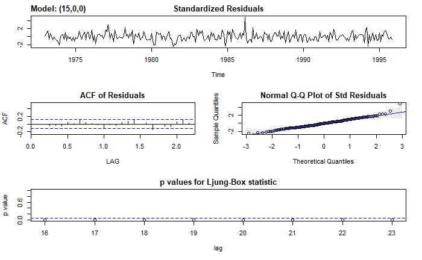

```r
sarima(sales_ts_ohne_na, 15,0,0)$ttable
```

```
      Estimate     SE t.value p.value
ar1     0.8732 0.0595 14.6777  0.0000
ar2    -0.0292 0.0782 -0.3729  0.7095
ar3    -0.0822 0.0779 -1.0557  0.2921
ar4    -0.0605 0.0775 -0.7815  0.4352
ar5     0.1595 0.0772  2.0660  0.0398
ar6    -0.0091 0.0777 -0.1176  0.9065
ar7     0.0212 0.0773  0.2741  0.7843
ar8    -0.0602 0.0773 -0.7783  0.4371
ar9    -0.0313 0.0771 -0.4056  0.6854
ar10    0.2014 0.0754  2.6705  0.0081
ar11   -0.0372 0.0763 -0.4875  0.6263
ar12    0.2892 0.0755  3.8330  0.0002
ar13   -0.1859 0.0775 -2.3975  0.0172
ar14    0.0155 0.0784  0.1975  0.8436
ar15   -0.1311 0.0784 -1.6728  0.0956
ar16    0.0029 0.0790  0.0372  0.9704
ar17    0.0658 0.0790  0.8327  0.4058
ar18   -0.1585 0.0790 -2.0055  0.0460
ar19    0.1082 0.0796  1.3590  0.1754
ar20   -0.2335 0.0798 -2.9270  0.0037
ar21    0.1507 0.0611  2.4676  0.0143
xmean  52.6856 2.1056 25.0221  0.0000
```

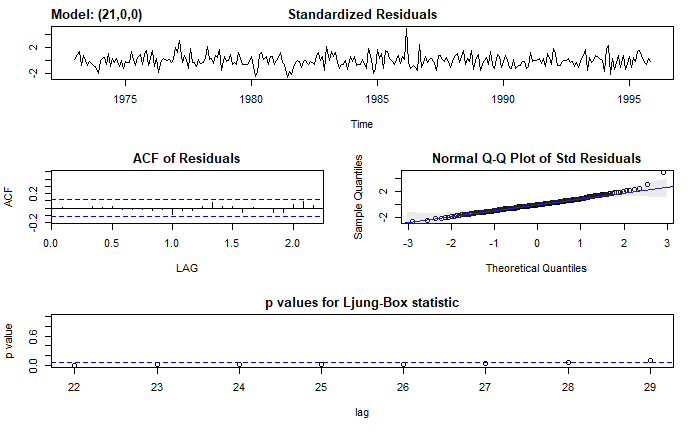

```r
sarima(sales_ts_ohne_na, 21,0,0)$ttable
```

**Welche Modell ist am Besten?: Mit AIC oder BIC.**

AIC:

```r
#Mit AIC
sarima(sales_ts_ohne_na,10,0,0)$AIC
```

```
[1] 4.356501
```

```
[1] 4.192116
```

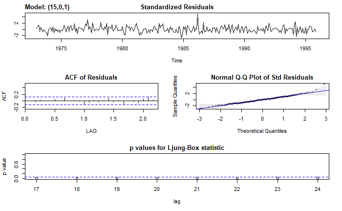

```r
sarima(sales_ts,15,0,1)$AIC
```

```
[1] 4.212936
```

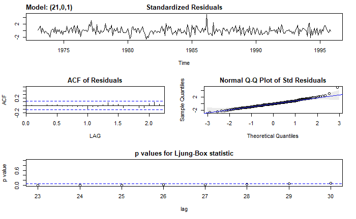

```r
sarima(sales_ts_ohne_na,21,0,1)$AIC
```

BIC:

```r
#Mit BIC
sarima(sales_ts_ohne_na,10,0,0)$BIC
```

```
[1] 3.501172
```

```
[1] 3.414529
```

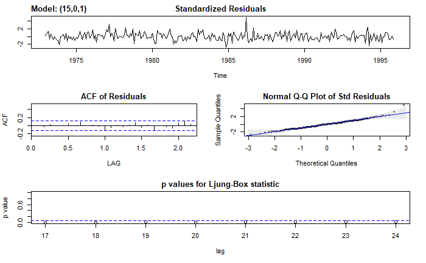

```r
sarima(sales_ts,15,0,1)$BIC
```

```
[1] 3.51543
```

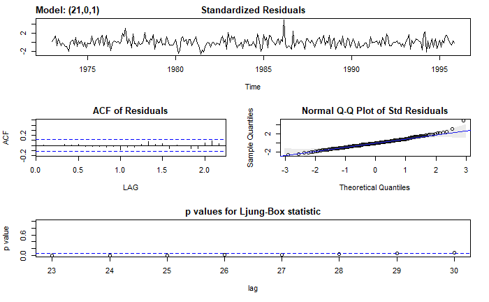

```r
sarima(sales_ts_ohne_na,21,0,1)$BIC
```

```r
#Residuen manuel entweder mit mm4_burg oder mm3_ols
layout(matrix(c(1,1,2,3), 2, 2, byrow = TRUE))
plot(mm4_burg$resid)
res=na.omit(mm4_burg$resid)
acf(res)
```

```r
Box.test(res, lag=20, type="Ljung-Box", fitdf=2)
```

```
    Box-Ljung test

data:  res
X-squared = 7.7008, df = 18, p-value = 0.9828
```

```r
qqnorm(res, main="Normal QQ-Plot")  # qq-plots
qqline(res, col=2)
```

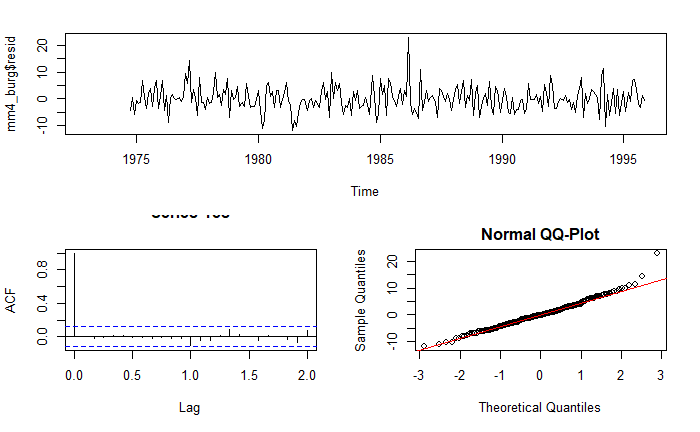

```r
par(mfrow=c(1,1))
```

```r
hist(res, prob=TRUE,16)   # histogram
lines(density(res))
```

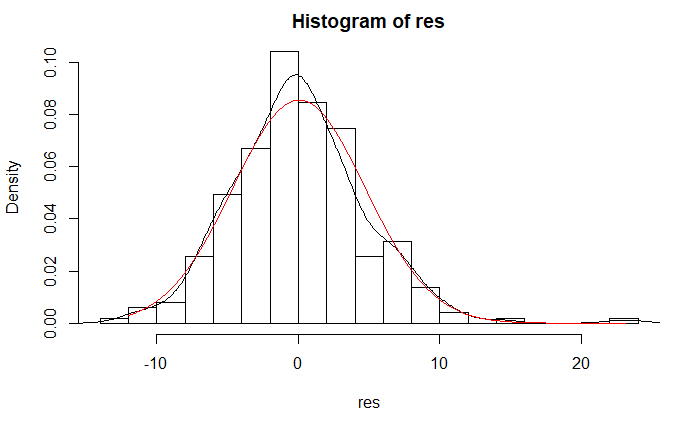

```r
dn=dnorm(x=seq(min(res),max(res),length.out=500), mean(res), sd(res))
lines(x=seq(min(res),max(res),length.out=500), dn, col=2)
```

```r
shapiro.test(res)          # passt nicht, vielleicht log besser
```

```
    Shapiro-Wilk normality test

data:  res
W = 0.97839, p-value = 0.0006571
```

### ARIMA Modelle (`auto.arima()`):

1. `auto.arima()` from forecast package erkennt die Modellen automatisch.

```r
fit_auto_arima<-auto.arima(sales_ts_ohne_na)
```

```r
(fit_auto_arima)
```

```
Series: sales_ts_ohne_na
ARIMA(1,0,0)(1,1,0)[12] with drift

Coefficients:
         ar1     sar1    drift
      0.8867  -0.4320  -0.0228
s.e.  0.0294   0.0569   0.1642

sigma^2 estimated as 27.92:  log likelihood=-811.38
AIC=1630.76   AICc=1630.92   BIC=1645.05
```

> fit<-Arima(sales_ts_ohne_na,order = c(1,0,0),seasonal = c(1,0,0),include.drift = TRUE)